# The deadliest cat in the world

Lina Lüttgert

10/03/2021

## The black-footed cat *(Felis nigripes)*

### Fun facts

The black-footed cat is a fascinating species endemic to the arid steppes and grassland savannas of Southern Africa. Although it only has a body length of about 35–52 cm and is indeed the smallest wild cat in Africa, its hunt success rate is spectacular: 60% of all hunting attempt are succesfull, making it the deadliest cat in the world. This innocent looking species is nocturnal and can capture more prey in a single night than a leopard does in six months. The poor victims are mostly rodents and birds.  
Despite of this killers outstanding hunting abilities, it is considered vulnerable to extinction by the IUCN. Unsurprisingly, the decline in population is suspected to be caused by humans, mainly due to the poaching of its prey species.  
(Unreliable references can be found at [Wikipedia](https://en.wikipedia.org/wiki/Black-footed_cat#Hunting_and_diet) and [FOX13](https://www.fox13news.com/news/worlds-deadliest-cats-get-first-taste-of-meat-at-san-diego-zoo))

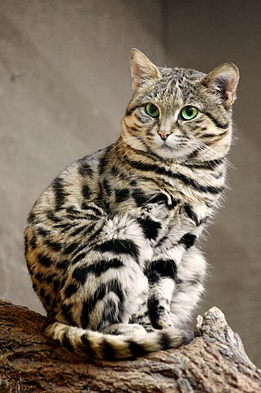

**Figure 1.** *Felis nigripes* looking confused and all innocent

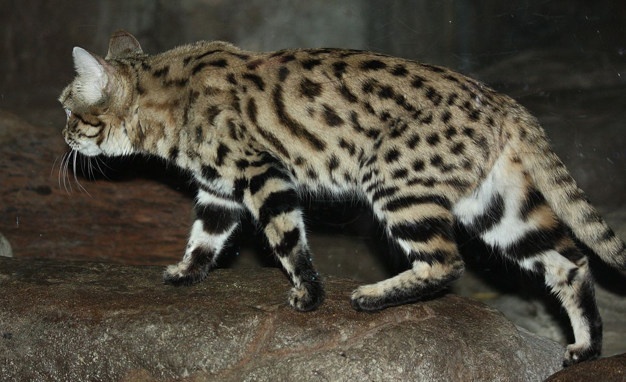

**Figure 2.** *Felis nigripes* ready to kill

### Occurrences

```r
library(tidyverse)
library(rgbif)
myspecies <- "Felis nigripes"
get.speciesKey <- function(x){name_backbone(x)$speciesKey} #get GBIF species key
key <- get.speciesKey(myspecies)
# extract the first n occurrences from rgbif
get.occurrences <- function(x, n=100){occ_search(taxonKey=x, return="data",
                                             limit=n, hasCoordinate = T)}
# clean data
dat <- lapply(key, get.occurrences, n=100)[[1]]
dat <- dat$data  %>%
  dplyr::select(species, year:day, country, stateProvince,
                decimalLongitude, decimalLatitude)#, everything())
```

```r
library(kableExtra)
knitr::kable(dat, caption="Table 1. Occurrences of Felis nigripes derived from GBIF") %>%
  kable_styling(
    bootstrap_options = c("striped", "hover", "condensed", "responsive"),
    position = "center")
```

Table 1. Occurrences of Felis nigripes derived from GBIF

[output not shown]

### Distribution map

```r
library(leaflet)
# create the gbif-violet style raster layer
projection = '3857' # projection code
style = 'style=gbif-violet' # style
tileRaster = paste0('https://tile.gbif.org/',projection,'/omt/{z}/{x}/{y}@1x.png?',style)
# create our polygons layer
prefix = 'https://api.gbif.org/v2/map/occurrence/density/{z}/{x}/{y}@1x.png?'
polygons = 'style=classic.poly&bin=hex&hexPerTile=70' # ploygon styles
taxonKey = 'taxonKey=2435037' # taxonKey of Felis nigripes
tilePolygons = paste0(prefix,polygons,'&',taxonKey)
# plot the styled map
leaflet() %>%
setView(lng = 5.4265362, lat = 43.4200248, zoom = 01) %>%
addTiles(urlTemplate=tileRaster) %>%
addTiles(urlTemplate=tilePolygons)
```

[interactive chart not shown]

**Figure 3.** Occurrences of *Felis nigripes* derived from GBIF